# Machine Learning Project 3 - Healthcare

### Loading Libraries

```python
import numpy as np
import pandas as pd
import matplotlib.pyplot as plt
import seaborn as sns
```

### Loading the Data

```python
data = pd.read_excel("cardio_health_dataset.xlsx")
```

## 1. Preliminary Analysis

### 1.a Perform preliminary data inspection and report the findings on the structure of the data, missing values, duplicates, etc.

```python
data.head()
```

|  | age | sex | cp | trestbps | chol | fbs | restecg | thalach | exang | oldpeak | slope | ca | thal | target |
| --- | --- | --- | --- | --- | --- | --- | --- | --- | --- | --- | --- | --- | --- | --- |
| 0 | 63 | 1 | 3 | 145 | 233 | 1 | 0 | 150 | 0 | 2.3 | 0 | 0 | 1 | 1 |
| 1 | 37 | 1 | 2 | 130 | 250 | 0 | 1 | 187 | 0 | 3.5 | 0 | 0 | 2 | 1 |
| 2 | 41 | 0 | 1 | 130 | 204 | 0 | 0 | 172 | 0 | 1.4 | 2 | 0 | 2 | 1 |
| 3 | 56 | 1 | 1 | 120 | 236 | 0 | 1 | 178 | 0 | 0.8 | 2 | 0 | 2 | 1 |
| 4 | 57 | 0 | 0 | 120 | 354 | 0 | 1 | 163 | 1 | 0.6 | 2 | 0 | 2 | 1 |

```python
data.tail()
```

|  | age | sex | cp | trestbps | chol | fbs | restecg | thalach | exang | oldpeak | slope | ca | thal | target |
| --- | --- | --- | --- | --- | --- | --- | --- | --- | --- | --- | --- | --- | --- | --- |
| 298 | 57 | 0 | 0 | 140 | 241 | 0 | 1 | 123 | 1 | 0.2 | 1 | 0 | 3 | 0 |
| 299 | 45 | 1 | 3 | 110 | 264 | 0 | 1 | 132 | 0 | 1.2 | 1 | 0 | 3 | 0 |
| 300 | 68 | 1 | 0 | 144 | 193 | 1 | 1 | 141 | 0 | 3.4 | 1 | 2 | 3 | 0 |
| 301 | 57 | 1 | 0 | 130 | 131 | 0 | 1 | 115 | 1 | 1.2 | 1 | 1 | 3 | 0 |
| 302 | 57 | 0 | 1 | 130 | 236 | 0 | 0 | 174 | 0 | 0.0 | 1 | 1 | 2 | 0 |

```python
data.columns
```

```
Index(['age', 'sex', 'cp', 'trestbps', 'chol', 'fbs', 'restecg', 'thalach',
       'exang', 'oldpeak', 'slope', 'ca', 'thal', 'target'],
      dtype='object')
```

```python
data.info()
```

```
<class 'pandas.core.frame.DataFrame'>
RangeIndex: 303 entries, 0 to 302
Data columns (total 14 columns):
 #   Column    Non-Null Count  Dtype
---  ------    --------------  -----
 0   age       303 non-null    int64
 1   sex       303 non-null    int64
 2   cp        303 non-null    int64
 3   trestbps  303 non-null    int64
 4   chol      303 non-null    int64
 5   fbs       303 non-null    int64
 6   restecg   303 non-null    int64
 7   thalach   303 non-null    int64
 8   exang     303 non-null    int64
 9   oldpeak   303 non-null    float64
 10  slope     303 non-null    int64
 11  ca        303 non-null    int64
 12  thal      303 non-null    int64
 13  target    303 non-null    int64
dtypes: float64(1), int64(13)
memory usage: 33.3 KB
```

**Observations:**

- There are 303 entries and 14 columns
- All varaibles are type int64 except oldpeak which is a float
- There are no null values

```python
data.isna().sum(axis=0)
```

```
age         0
sex         0
cp          0
trestbps    0
chol        0
fbs         0
restecg     0
thalach     0
exang       0
oldpeak     0
slope       0
ca          0
thal        0
target      0
dtype: int64
```

```python
data[data.duplicated()==True]
```

|  | age | sex | cp | trestbps | chol | fbs | restecg | thalach | exang | oldpeak | slope | ca | thal | target |
| --- | --- | --- | --- | --- | --- | --- | --- | --- | --- | --- | --- | --- | --- | --- |
| 164 | 38 | 1 | 2 | 138 | 175 | 0 | 1 | 173 | 0 | 0.0 | 2 | 4 | 2 | 1 |

**Observations:**

- There aren't any null values
- There appears to be one duplicated value. We will drop that value.

### 1.b Based on these findings, remove duplicates (if any) and treat missing values using an appropriate strategy

```python
data = data.drop_duplicates()
```

```python
data.info()
```

```
<class 'pandas.core.frame.DataFrame'>
Int64Index: 302 entries, 0 to 302
Data columns (total 14 columns):
 #   Column    Non-Null Count  Dtype
---  ------    --------------  -----
 0   age       302 non-null    int64
 1   sex       302 non-null    int64
 2   cp        302 non-null    int64
 3   trestbps  302 non-null    int64
 4   chol      302 non-null    int64
 5   fbs       302 non-null    int64
 6   restecg   302 non-null    int64
 7   thalach   302 non-null    int64
 8   exang     302 non-null    int64
 9   oldpeak   302 non-null    float64
 10  slope     302 non-null    int64
 11  ca        302 non-null    int64
 12  thal      302 non-null    int64
 13  target    302 non-null    int64
dtypes: float64(1), int64(13)
memory usage: 35.4 KB
```

**Observation:** Removed the duplicate entry

## 2. Prepare a report about the data explaining the distribution of the disease and the related factors

### 2.a Get a preliminary statistical summary of the data and explore the measures of central tendencies and spread of the data

```python
data.describe().T
```

|  | count | mean | std | min | 25% | 50% | 75% | max |
| --- | --- | --- | --- | --- | --- | --- | --- | --- |
| age | 302.0 | 54.420530 | 9.047970 | 29.0 | 48.00 | 55.5 | 61.00 | 77.0 |
| sex | 302.0 | 0.682119 | 0.466426 | 0.0 | 0.00 | 1.0 | 1.00 | 1.0 |
| cp | 302.0 | 0.963576 | 1.032044 | 0.0 | 0.00 | 1.0 | 2.00 | 3.0 |
| trestbps | 302.0 | 131.602649 | 17.563394 | 94.0 | 120.00 | 130.0 | 140.00 | 200.0 |
| chol | 302.0 | 246.500000 | 51.753489 | 126.0 | 211.00 | 240.5 | 274.75 | 564.0 |
| fbs | 302.0 | 0.149007 | 0.356686 | 0.0 | 0.00 | 0.0 | 0.00 | 1.0 |
| restecg | 302.0 | 0.526490 | 0.526027 | 0.0 | 0.00 | 1.0 | 1.00 | 2.0 |
| thalach | 302.0 | 149.569536 | 22.903527 | 71.0 | 133.25 | 152.5 | 166.00 | 202.0 |
| exang | 302.0 | 0.327815 | 0.470196 | 0.0 | 0.00 | 0.0 | 1.00 | 1.0 |
| oldpeak | 302.0 | 1.043046 | 1.161452 | 0.0 | 0.00 | 0.8 | 1.60 | 6.2 |
| slope | 302.0 | 1.397351 | 0.616274 | 0.0 | 1.00 | 1.0 | 2.00 | 2.0 |
| ca | 302.0 | 0.718543 | 1.006748 | 0.0 | 0.00 | 0.0 | 1.00 | 4.0 |
| thal | 302.0 | 2.314570 | 0.613026 | 0.0 | 2.00 | 2.0 | 3.00 | 3.0 |
| target | 302.0 | 0.543046 | 0.498970 | 0.0 | 0.00 | 1.0 | 1.00 | 1.0 |

```python
def hist_and_box_plot(col):
    print(col)

    print('Skew :', round(data[col].skew(), 2))

    plt.figure(figsize = (15, 4))

    plt.subplot(1, 2, 1)

    data[col].hist()

    plt.ylabel('count')

    plt.subplot(1, 2, 2)

    sns.boxplot(x = data[col])

    plt.show()
```

```
age
Skew : -0.2
```

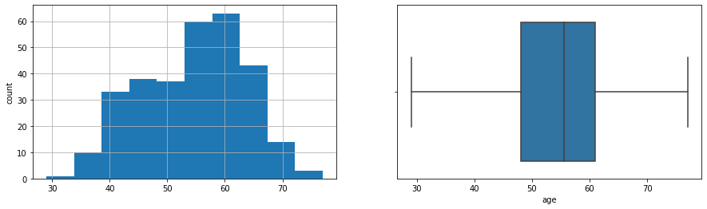

```python
hist_and_box_plot("age")
```

**Observations:** Age seems to be well distributed from 29 to 77 with many observations being between 55 and 65.

```
sex
Skew : -0.79
```

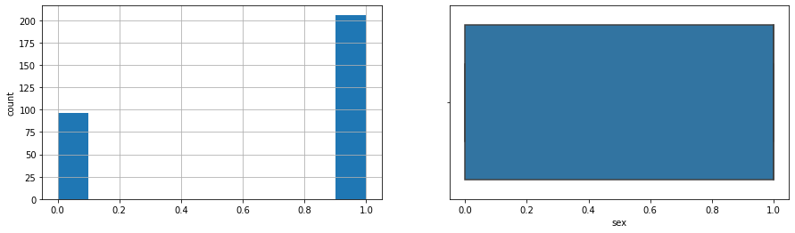

```python
hist_and_box_plot("sex")
```

**Observations:** There appears to be about twice as many men as women. This is a categorical variable.

```
cp
Skew : 0.49
```

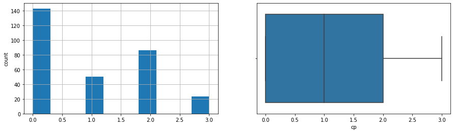

```python
hist_and_box_plot("cp")
```

**Observations:** A Chest pain type of 0 was most common followed by 2, 1, then 3. This data is categorical.

```
trestbps
Skew : 0.72
```

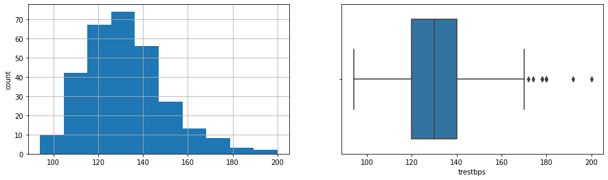

```python
hist_and_box_plot("trestbps")
```

**Observations:** The data has a positive skew with a majority of the values being between about 110 and 145.

```
chol
Skew : 1.15
```

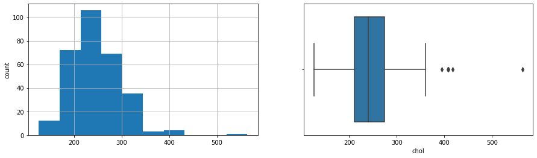

```python
hist_and_box_plot("chol")
```

**Observations:** Cholesterol has a positive skew with a few outliers. The median is 240.5

```
fbs
Skew : 1.98
```

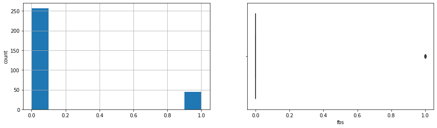

```python
hist_and_box_plot("fbs")
```

**Observations:** The majority of people had a fasting blood sugar less than 120mg/dl. This is a categorical variable.

```
restecg
Skew : 0.17
```

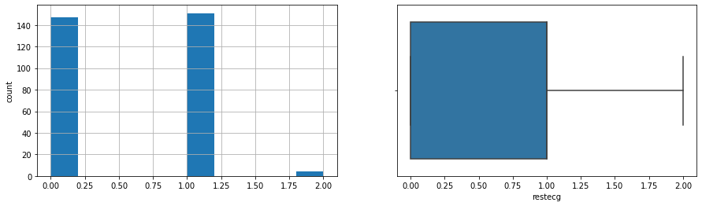

```python
hist_and_box_plot("restecg")
```

**Observations:** I'm not sure what this means but it looks categorical. Almost all cases are 0 or 1.

```
thalach
Skew : -0.53
```

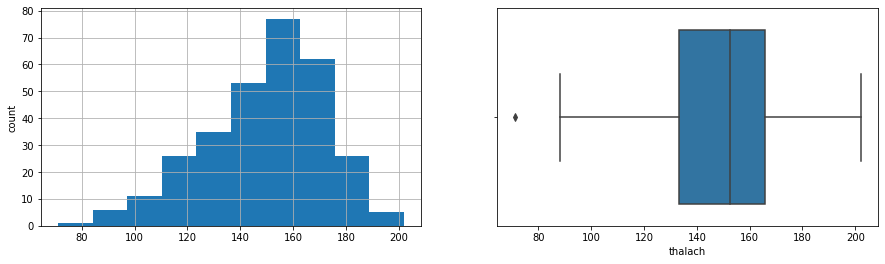

```python
hist_and_box_plot("thalach")
```

**Observations:** There is a good distribution of maximum heart rate achieved with a slight negative skew. The median is 152.5bpm

```
exang
Skew : 0.74
```

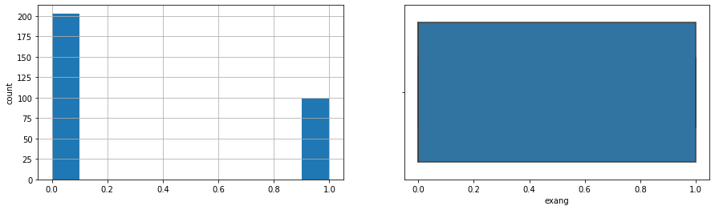

```python
hist_and_box_plot("exang")
```

**Observations:** About twice as many people do not have exercise induced angina compared to those that do have it. This is a categorical variable

```
oldpeak
Skew : 1.27
```

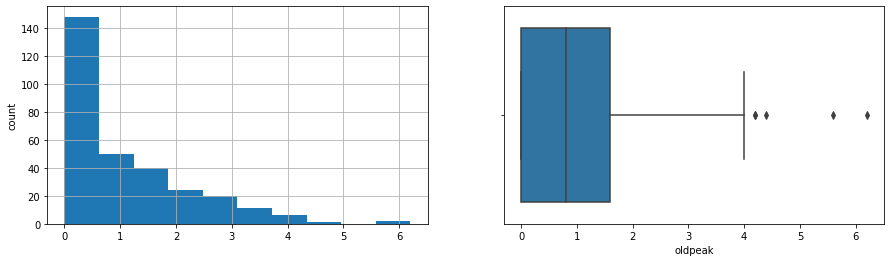

```python
hist_and_box_plot("oldpeak")
```

**Observations:** The most common value is zero and there is a positive skew.

```
slope
Skew : -0.5
```

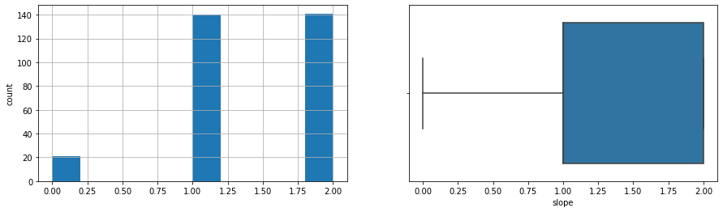

```python
hist_and_box_plot("slope")
```

**Observations:** Most people have a value of 1 or 2. This data appears to be categorical.

```
ca
Skew : 1.3
```

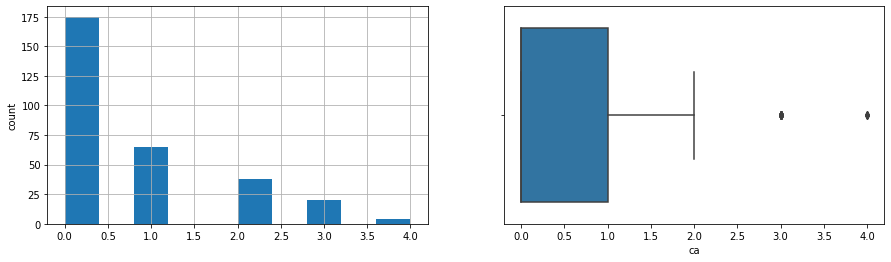

```python
hist_and_box_plot("ca")
```

**Observations:** The most common value is zero. This is categorical data.

```
thal
Skew : -0.48
```

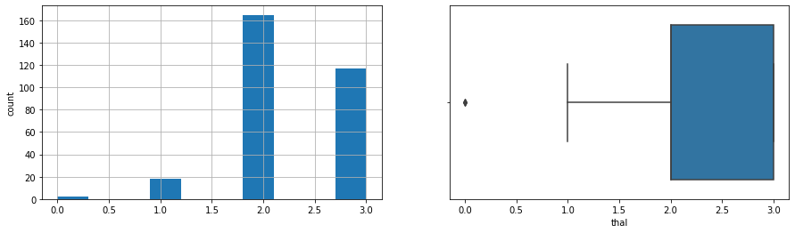

```python
hist_and_box_plot("thal")
```

**Observations:** The data description says these valeus should be 3, 6, and 7 but they are 0, 1, 2, and 3. The most common is 2 followed by 3. This is categorical data.

```
target
Skew : -0.17
```

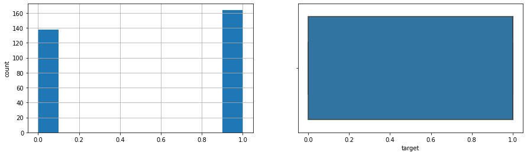

```python
hist_and_box_plot("target")
```

**Observations:** Target is supposed to be wether or not someone had a heart attack. There is about a 50/50 split between the people who have and have not had a heart attack in this data. This dataset is balanced.

### 2.b dentify the data variables which are categorical and describe and explore these variables using the appropriate tools, such as count plot

In the previous section, we identified sex, cp, fbs, restecg, exang, slope, ca, and thal as being categorical data.

```python
categorical_labels = ["sex", "cp", "fbs", "restecg", "exang", "slope", "ca", "thal"]
```

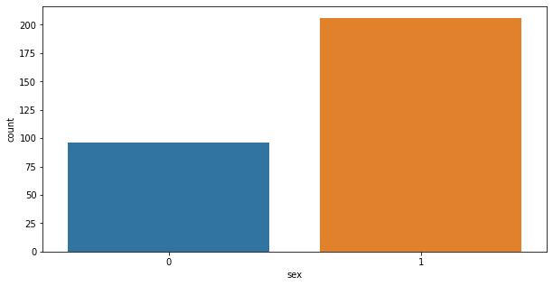

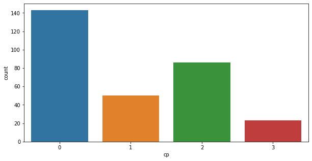

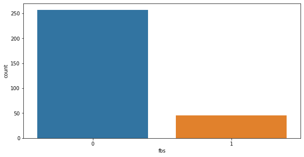

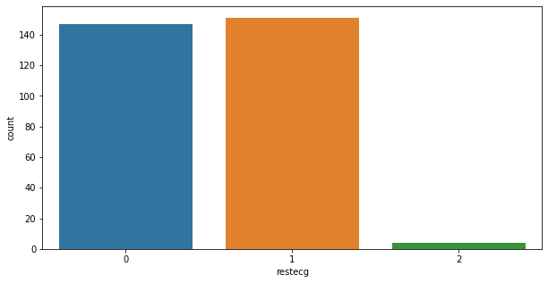

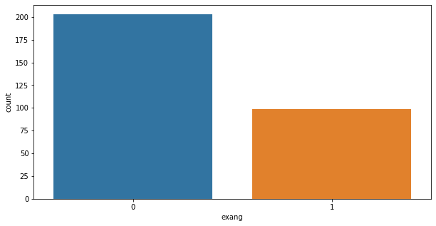

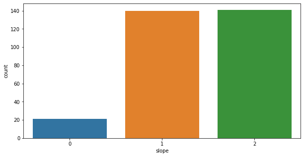

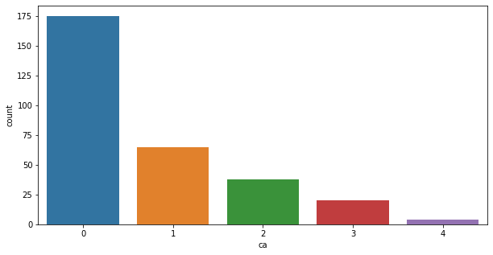

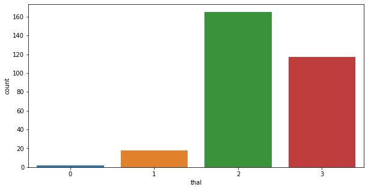

```python
for label in categorical_labels:

    plt.figure(figsize = (10, 5))

    sns.countplot(data=data, x=label)

    plt.show()
```

### 2.c Study the occurrence of CVD across the Age category

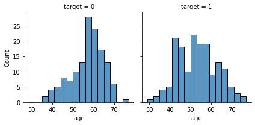

```python
sns.displot(
    data, x="age", col="target",
    binwidth=3, height=3, facet_kws=dict(margin_titles=True),
)
```

```
age
Skew : -0.2
```

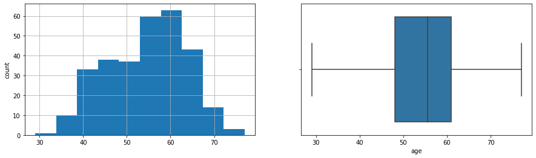

```python
hist_and_box_plot("age")
```

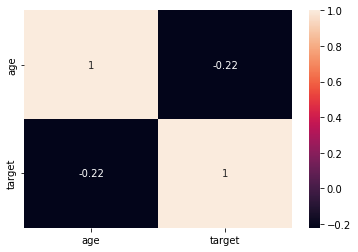

```python
sns.heatmap(data[["age","target"]].corr(), annot=True)
```

**Observations:** The data so far doesn't make much intuitive sens to me. I would have expected age to be positively correlated with CVD but it does not seem to be based on these histograms. This could be due to sampling though.

### 2.d Study the composition of all patients with respect to the Sex category

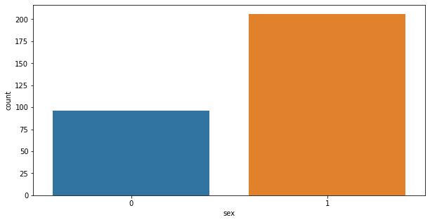

```python
plt.figure(figsize = (10, 5))

sns.countplot(data=data, x="sex")

plt.show()
```

**Observations:** There are about twice as many males as females in this sample

## 2.e Study if one can detect heart attacks based on anomalies in the resting blood pressure (trestbps) of a patient

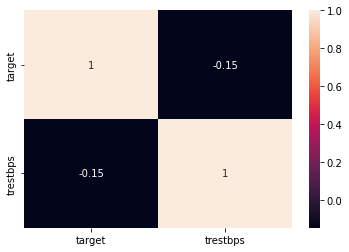

```python
sns.heatmap(data[["target","trestbps"]].corr(), annot=True)
```

**Observations:** Resting blood pressure seems to be slightly negatively correlated with CVD. I would have expected there to be a strong positive correlation. I'm not sure why this is the result.

### 2.f Describe the relationship between cholesterol levels and a target variable

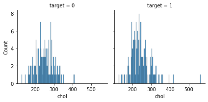

```python
sns.displot(
    data, x="chol", col="target",
    binwidth=3, height=3, facet_kws=dict(margin_titles=True),
)
```

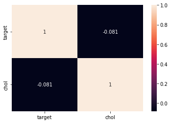

```python
sns.heatmap(data[["target","chol"]].corr(), annot=True)
```

**Observations:** There appears to be almost no correlation between cholesterol and CVD in this data.

### 2.g State what relationship exists between peak exercising and the occurrence of a heart attack

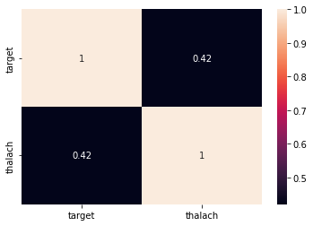

```python
sns.heatmap(data[["target","thalach"]].corr(), annot=True)
```

**Observations:** There appears to be a moderate positive correlation between peak exercising heart rate and CVD

### 2.h Check if thalassemia is a major cause of CVD

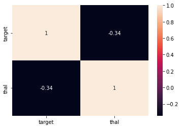

```python
sns.heatmap(data[["target","thal"]].corr(), annot=True)
```

### 2.i List how the other factors determine the occurrence of CVD

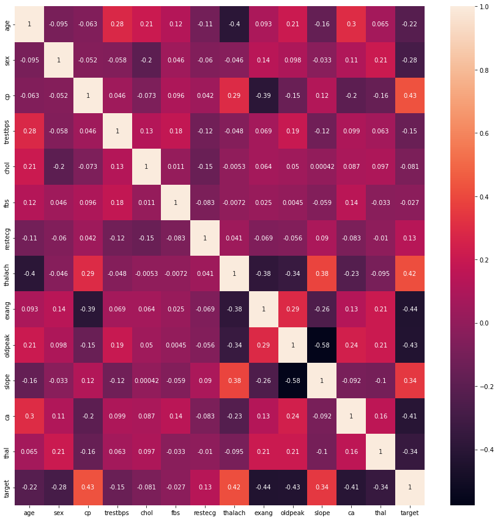

```python
plt.figure(figsize = (15, 15))

sns.heatmap(data.corr(), annot=True)

plt.show()
```

**Observations:**

- Chest pain type, Max heart rate achieved, and Slope have moderate positive correlations with CVD
- Exercise induced angina, oldpeak, ca, and thal seem to have moderate negative correlations with CVD